# INDE546_HW5

Michael Shieh

2/6/2020

# Exercise 1

##### First, import dataset as survey:

```r
survey <- read.csv("Class_Survey_W20.csv", header = TRUE)
```

##### The dependent variable I have chosen for this logistic regression model is **whether the participants have involved in a car crash or not in the past 5 years**, where there are two levels (Yes and No).

```r
survey <- survey %>%
  rename(CarCrash = In.the.past.5.years..how.many.times.have.you.been.involved.in.a.car.crash..) %>%
  drop_na(CarCrash) %>%
  mutate(CarCrash = ifelse(CarCrash == 0, 0, 1))
```

##### The first independent variable I have chosen is **how often do the participants go on campus every week**, where there are two levels (high and low). I chose this variable because I think if you stay at home more often, it is more unlikely that you will encounter a car crash.

```r
survey <- survey %>% rename(OnCampusFreq = In.an.average.week..how.many.days.are.you.on.the.UW.campus.)
survey <- survey %>% drop_na(OnCampusFreq)
survey <- survey %>% mutate(OnCampusFreq = ifelse(grepl('Every', survey$OnCampusFreq), 1, 0))

survey$OnCampusFreq <- factor(survey$OnCampusFreq, levels = c("0", "1"), labels = c("Low", "High"))
```

##### The second independent variable I have chosen is **do participants sort wastes properly**, where there are two levels (Yes and No). I chose this variable because I think if people follow traffic laws, they should encounter less car crashes. If willing to follow laws, they might be more willing to sort wastes properly. I am curios to see the relationships between the two variables.

```r
survey <- survey %>%
  rename(ProperlySort = How.often.....do.you.properly.sort.waste.into.trash..recyclables.and.compost.) %>%
  drop_na(ProperlySort) %>%
  mutate(ProperlySort = ifelse(ProperlySort == 'Never', 0, 1))

survey$ProperlySort <- factor(survey$ProperlySort, levels = c("0", "1"), labels = c("No", "Yes"))
```

##### The third independent variable I have chosen is **the age of the participants**, where this is a continuous variable. I chose this variable because I believe age is definitely sharing a meaningful relationship with the dependent variable.

```r
survey <- survey %>%
  rename(Age = How.old.are.you.) %>%
  filter(Age > 0)
```

##### The forth independent variable I have chosen is **how long do the participants own driver’s licenses**, where this is a continuous variable. I chose this variable because I think that the longer you drive, you more experiences you have. Therefore, it should be more unlikely to encounter a car crash if you hold a driver’s license longer.

```r
survey <- survey %>%
  rename(DLAge = How.old.were.you.when.you.got.your.driver.s.license.) %>%
  filter(DLAge > 0) %>%
  mutate(DL_Length = Age - DLAge)
```

##### The fifth independent variable I have chosen is **how often do participants drive weekly compare to other participants**, where there are two levels (above average and below average) I chose this variable because I think if you drive more frequently than others, it is more likely that you got involved in a car crash.

```r
survey <- survey %>%
  rename(DriveFreq = On.average..how.many.days.in.a.week..out.of.7.days..do.you.drive.) %>%
  filter(DriveFreq >= 0) %>%
  mutate(DriveFreq = ifelse(DriveFreq >= mean(DriveFreq), 1, 0))

survey$DriveFreq <- factor(survey$DriveFreq, levels = c("0", "1"), labels = c("BelowAvg", "AboveAvg"))
```

##### The sixth variable I have chosen is **the gender of the participants**, where there are two levels (male and female).

##### I chose this variable because I want to see if gender effect the frequency of involving in a car crash.

```r
survey <- survey %>%
  rename(Gender = Are.you..1) %>%
  filter(Gender %in% c('Male', 'Female')) %>%
  mutate(Gender = case_when(Gender == 'Male' ~ 1, Gender == 'Female' ~ 0))

survey$Gender <- factor(survey$Gender, levels = c("0", "1"), labels = c("Female", "Male"))
```

##### Next, I put all variables into the regression model.

```r
LB_HW5 <- glm(CarCrash ~ Age + OnCampusFreq + ProperlySort + DL_Length + DriveFreq + Gender, data = survey, family = binomial())
summary(LB_HW5)
```

```
##
## Call:
## glm(formula = CarCrash ~ Age + OnCampusFreq + ProperlySort +
##     DL_Length + DriveFreq + Gender, family = binomial(), data = survey)
##
## Deviance Residuals:
##     Min       1Q   Median       3Q      Max
## -2.2169  -0.8458   0.4495   0.5685   1.8551
##
## Coefficients:
##                    Estimate Std. Error z value Pr(>|z|)
## (Intercept)        3.260415   1.412524   2.308   0.0210 *
## Age                0.006479   0.046823   0.138   0.8899
## OnCampusFreqHigh   0.316322   0.307272   1.029   0.3033
## ProperlySortYes   -1.098622   1.058481  -1.038   0.2993
## DL_Length         -0.077845   0.046087  -1.689   0.0912 .
## DriveFreqAboveAvg -2.488619   0.299298  -8.315   <2e-16 ***
## GenderMale        -0.307753   0.298402  -1.031   0.3024
## ---
## Signif. codes:  0 '***' 0.001 '**' 0.01 '*' 0.05 '.' 0.1 ' ' 1
##
## (Dispersion parameter for binomial family taken to be 1)
##
##     Null deviance: 395.71  on 306  degrees of freedom
## Residual deviance: 288.69  on 300  degrees of freedom
## AIC: 302.69
##
## Number of Fisher Scoring iterations: 4
```

# Exercise 2

##### Since age is a very insignificant variable, I remove this variable to see if I can produce a better model.

```r
LB_HW5 <- glm(CarCrash ~ OnCampusFreq + ProperlySort + DL_Length + DriveFreq + Gender, data = survey, family = binomial())
summary(LB_HW5)
```

```
##
## Call:
## glm(formula = CarCrash ~ OnCampusFreq + ProperlySort + DL_Length +
##     DriveFreq + Gender, family = binomial(), data = survey)
##
## Deviance Residuals:
##     Min       1Q   Median       3Q      Max
## -2.2263  -0.8462   0.4485   0.5652   1.8517
##
## Coefficients:
##                   Estimate Std. Error z value Pr(>|z|)
## (Intercept)        3.38087    1.11324   3.037 0.002390 **
## OnCampusFreqHigh   0.31476    0.30692   1.026 0.305105
## ProperlySortYes   -1.08871    1.05552  -1.031 0.302329
## DL_Length         -0.07212    0.02023  -3.565 0.000364 ***
## DriveFreqAboveAvg -2.48813    0.29918  -8.317  < 2e-16 ***
## GenderMale        -0.31014    0.29794  -1.041 0.297894
## ---
## Signif. codes:  0 '***' 0.001 '**' 0.01 '*' 0.05 '.' 0.1 ' ' 1
##
## (Dispersion parameter for binomial family taken to be 1)
##
##     Null deviance: 395.71  on 306  degrees of freedom
## Residual deviance: 288.71  on 301  degrees of freedom
## AIC: 300.71
##
## Number of Fisher Scoring iterations: 4
```

##### After removing the variable age, I noticed that there is a new significant variable occured. Next, I removed all insignificant variable to see if I can furthur improve the model.

```r
LB_HW5 <- glm(CarCrash ~ DL_Length + DriveFreq, data = survey, family = binomial())
summary(LB_HW5)
```

```
##
## Call:
## glm(formula = CarCrash ~ DL_Length + DriveFreq, family = binomial(),
##     data = survey)
##
## Deviance Residuals:
##     Min       1Q   Median       3Q      Max
## -2.2033  -0.8885   0.4600   0.5435   1.9414
##
## Coefficients:
##                   Estimate Std. Error z value Pr(>|z|)
## (Intercept)        2.33474    0.27283   8.558  < 2e-16 ***
## DL_Length         -0.07100    0.02029  -3.499 0.000466 ***
## DriveFreqAboveAvg -2.49262    0.29529  -8.441  < 2e-16 ***
## ---
## Signif. codes:  0 '***' 0.001 '**' 0.01 '*' 0.05 '.' 0.1 ' ' 1
##
## (Dispersion parameter for binomial family taken to be 1)
##
##     Null deviance: 395.71  on 306  degrees of freedom
## Residual deviance: 291.44  on 304  degrees of freedom
## AIC: 297.44
##
## Number of Fisher Scoring iterations: 4
```

```r
x <- data.frame("Variable Names" = c('Length of having drivers license', 'Above average frequency of driving'), "coefficients" = LB_HW5$coefficients[2:3], "z-value" = c('-3.499', '-8.441'), "Significance" = c('Yes', 'Yes'))
x
```

```
##                                       Variable.Names coefficients z.value
## DL_Length           Length of having drivers license  -0.07099598  -3.499
## DriveFreqAboveAvg Above average frequency of driving  -2.49262368  -8.441
##                   Significance
## DL_Length                  Yes
## DriveFreqAboveAvg          Yes
```

##### Next, I look at the relative risk and odds ratio.

```r
table <- table(survey$DriveFreq, survey$CarCrash)
colnames(table) = c("No Crash", "Crash")
table
```

```
##
##            No Crash Crash
##   BelowAvg       26   160
##   AboveAvg       80    41
```

##### P(BelowAvg+Crash) = 160/186 = 0.8602, P(AboveAvg+Crash) = 41/121 = 0.3388, Relative Risk = 0.8602/0.3388 = 2.5390.

##### Odds(BelowAvg+Crash) = 160/26 = 6.1538, Odds(AboveAvg+Crash) = 41/80 = 0.5125, Odds Ratio = 6.1538/0.5125 = 12.0074.

##### Both numbers show that the below-average-frequency drivers are more crash-prone when driving.

##### Then I plotted the logit curve

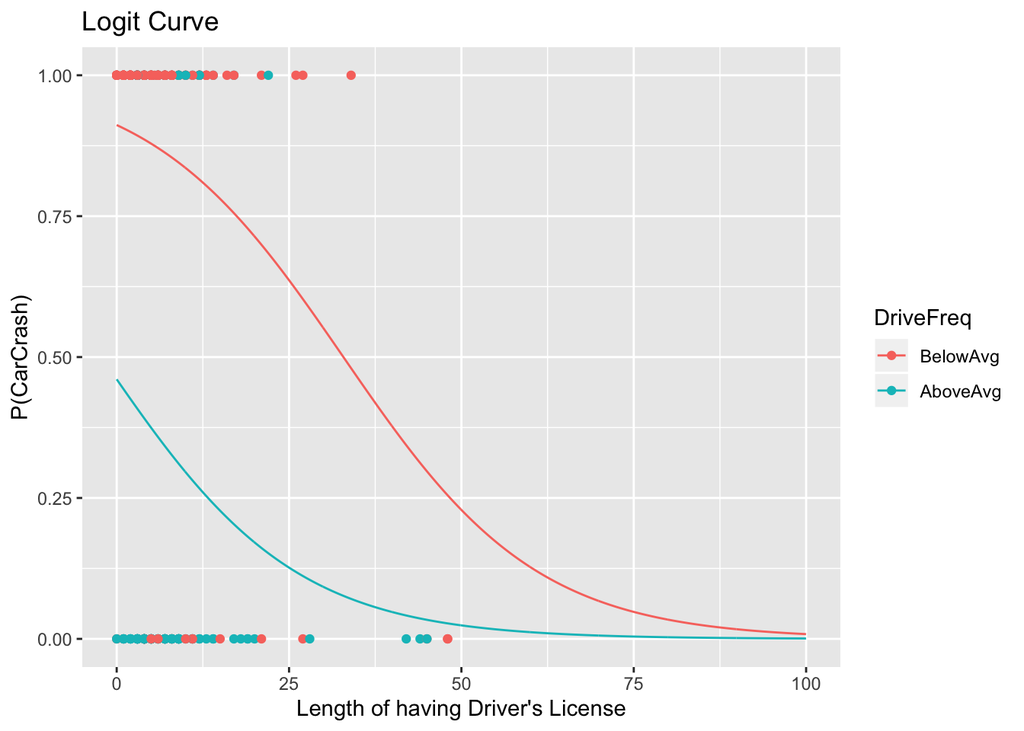

```r
generated_data <- as.data.frame(expand.grid(DL_Length = seq(min(survey$DL_Length), 100, 0.1), DriveFreq = c('BelowAvg','AboveAvg')))
generated_data$probs <- plogis(predict(LB_HW5, newdata = generated_data))

ggplot(generated_data, aes(x = DL_Length, y = probs, color = DriveFreq)) +
  geom_line() +
  geom_point(data = survey, aes(x = DL_Length, y = CarCrash)) +
  labs(x = "Length of having Driver's License", y = "P(CarCrash)", title = "Logit Curve")+
  ylim(c(0, 1))
```

##### The logit curve shows that if you drive frequently, you are less likely to get involved in a car crash, but if you own a driver license longer, you are decreasing your odds of encountering a car crash. This result could connect the cause of car crashes to inexperience drivers who just acquire their driver’s licenses more based on the result of this model.

# Exercise 3

```r
LB_HW5 <- glm(CarCrash ~ Gender + DL_Length + DriveFreq + Gender*DriveFreq + OnCampusFreq*DriveFreq, data = survey, family = binomial())
summary(LB_HW5)
```

```
##
## Call:
## glm(formula = CarCrash ~ Gender + DL_Length + DriveFreq + Gender *
##     DriveFreq + OnCampusFreq * DriveFreq, family = binomial(),
##     data = survey)
##
## Deviance Residuals:
##     Min       1Q   Median       3Q      Max
## -2.3306  -0.7875   0.4460   0.5502   1.9354
##
## Coefficients:
##                                    Estimate Std. Error z value Pr(>|z|)
## (Intercept)                         2.71674    0.52655   5.160 2.48e-07 ***
## GenderMale                         -0.31977    0.44401  -0.720 0.471410
## DL_Length                          -0.06943    0.02023  -3.432 0.000599 ***
## DriveFreqAboveAvg                  -3.11887    0.62719  -4.973 6.60e-07 ***
## OnCampusFreqHigh                   -0.30765    0.50604  -0.608 0.543215
## GenderMale:DriveFreqAboveAvg       -0.01212    0.60124  -0.020 0.983919
## DriveFreqAboveAvg:OnCampusFreqHigh  1.00789    0.65583   1.537 0.124338
## ---
## Signif. codes:  0 '***' 0.001 '**' 0.01 '*' 0.05 '.' 0.1 ' ' 1
##
## (Dispersion parameter for binomial family taken to be 1)
##
##     Null deviance: 395.71  on 306  degrees of freedom
## Residual deviance: 287.29  on 300  degrees of freedom
## AIC: 301.29
##
## Number of Fisher Scoring iterations: 4
```

```r
x <- data.frame("Variable Names" = c('Male', 'Length of having drivers license', 'Above average frequency of driving', 'Go on campus more frequently','Male who drive frequently', 'Participants who both go on campus and drive more frequently'), "coefficients" = LB_HW5$coefficients[2:7], "z-value" = c('-0.720', '-3.432', '-4.973', '-0.608', '-0.020', '1.537'), "Significance" = c('No', 'Yes', 'Yes', 'No', 'No', 'No'))
x
```

```
##                                                                                  Variable.Names
## GenderMale                                                                                 Male
## DL_Length                                                      Length of having drivers license
## DriveFreqAboveAvg                                            Above average frequency of driving
## OnCampusFreqHigh                                                   Go on campus more frequently
## GenderMale:DriveFreqAboveAvg                                          Male who drive frequently
## DriveFreqAboveAvg:OnCampusFreqHigh Participants who both go on campus and drive more frequently
##                                    coefficients z.value Significance
## GenderMale                          -0.31976925  -0.720           No
## DL_Length                           -0.06943462  -3.432          Yes
## DriveFreqAboveAvg                   -3.11887351  -4.973          Yes
## OnCampusFreqHigh                    -0.30764853  -0.608           No
## GenderMale:DriveFreqAboveAvg        -0.01211853  -0.020           No
## DriveFreqAboveAvg:OnCampusFreqHigh   1.00788812   1.537           No
```

##### The AIC increases by 3.85, which means the previous model is slightly better than this one. However, if I remove some variables and leave only significant variables remain in the model, I could probably improve the model by decreasing AIC. Which is the result below, as AIC decreases by 4.69.

```r
LB_HW5 <- glm(CarCrash ~ DL_Length + DriveFreq + DL_Length*DriveFreq, data = survey, family = binomial())
summary(LB_HW5)
```

```
##
## Call:
## glm(formula = CarCrash ~ DL_Length + DriveFreq + DL_Length *
##     DriveFreq, family = binomial(), data = survey)
##
## Deviance Residuals:
##     Min       1Q   Median       3Q      Max
## -2.2826  -0.9063   0.4294   0.5379   1.6374
##
## Coefficients:
##                             Estimate Std. Error z value Pr(>|z|)
## (Intercept)                  2.52845    0.31005   8.155 3.49e-16 ***
## DL_Length                   -0.09546    0.02704  -3.531 0.000414 ***
## DriveFreqAboveAvg           -3.00046    0.42510  -7.058 1.69e-12 ***
## DL_Length:DriveFreqAboveAvg  0.06977    0.04006   1.742 0.081544 .
## ---
## Signif. codes:  0 '***' 0.001 '**' 0.01 '*' 0.05 '.' 0.1 ' ' 1
##
## (Dispersion parameter for binomial family taken to be 1)
##
##     Null deviance: 395.71  on 306  degrees of freedom
## Residual deviance: 288.60  on 303  degrees of freedom
## AIC: 296.6
##
## Number of Fisher Scoring iterations: 4
```